# Classification in Python

## Outline / Steps to do the analysis

- Load the necessary packages into memory
- Use the "official classification" and create the labels for personality traits for every person in the dataset
- Train the models to be able to identify personalities of new individuals using:
  - Knn
  - Simple Tree
  - Random Forest
  - XGBoost
  - SVM
- Run classification for Alex's personality using the above-mentioned models

Let's start by loading in modules and data

```python
# The following two lines change the way
# the notebook is displayed
from IPython.core.display import display, HTML
display(HTML("<style>.container { width:90% !important; }</style>"))

# Now we load the important functions
import pandas as pd #For working with dataframes
import numpy as np #For working with arrays, pandas is built on top of this
from pprint import pprint #For printing things nicely
import matplotlib.pyplot as plt #For plotting
import seaborn as sns

# Now we can load the data
class_df = pd.read_csv('personality_tests.csv').iloc[4:,]
alex_df = pd.read_csv('alexahpenev_personality.csv')
display(class_df.head())
display(alex_df.head())
```

|  | StartDate | EndDate | Status | Progress | Duration (in seconds) | Finished | RecordedDate | DistributionChannel | UserLanguage | Q1 | ... | Q121 | Q122 | Q123 | Q124 | Q125 | Q127 | Q129 | Q133 | Q134 | Q137 |
| --- | --- | --- | --- | --- | --- | --- | --- | --- | --- | --- | --- | --- | --- | --- | --- | --- | --- | --- | --- | --- | --- |
| 4 | 2/20/20 15:13 | 2/20/20 15:24 | 0 | 100 | 648 | 1 | 2/20/20 15:24 | anonymous | EN | 3 | ... | 2 | 1 | 1 | 2 | 2 | 32 | 2 | 1 | NaN | NaN |
| 5 | 2/20/20 15:16 | 2/20/20 15:24 | 0 | 100 | 495 | 1 | 2/20/20 15:24 | qr | EN | 4 | ... | 1 | 2 | 1 | 1 | 1 | 22 | 2 | 1 | NaN | NaN |
| 6 | 2/20/20 15:13 | 2/20/20 15:25 | 0 | 100 | 718 | 1 | 2/20/20 15:25 | anonymous | EN | 4 | ... | 2 | 2 | 2 | 2 | 2 | 23 | 1 | 1 | NaN | NaN |
| 7 | 2/20/20 15:16 | 2/20/20 15:25 | 0 | 100 | 580 | 1 | 2/20/20 15:25 | anonymous | EN | 2 | ... | 2 | 2 | 2 | 1 | 2 | 30 | 2 | 1 | NaN | NaN |
| 8 | 2/20/20 15:12 | 2/20/20 15:26 | 0 | 100 | 836 | 1 | 2/20/20 15:26 | anonymous | EN | 5 | ... | 1 | 1 | 1 | 1 | 1 | 23 | 1 | 1 | NaN | NaN |

5 rows × 135 columns

|  | Q1 | Q4 | Q6 | Q7 | Q8 | Q9 | Q10 | Q11 | Q12 | Q13 | ... | Q116 | Q117 | Q118 | Q119 | Q120 | Q121 | Q122 | Q123 | Q124 | Q125 |
| --- | --- | --- | --- | --- | --- | --- | --- | --- | --- | --- | --- | --- | --- | --- | --- | --- | --- | --- | --- | --- | --- |
| 0 | 2 | 1 | 2 | 5 | 4 | 2 | 4 | 5 | 1 | 1 | ... | 1 | 1 | 1 | 2 | 2 | 2 | 1 | 1 | 1 | 1 |

1 rows × 121 columns

Let's separate our class data into two datasets. One for Big Five questions and one for MBTI. We'll convert all of the columns to numeric fields.

```python
# We separate the data into two separate questionnaires,
# one for Big5 and one for MBTI

bigfive_df = class_df.copy().loc[:,'Q1':'Q54']
mbti_df = class_df.copy().loc[:,'Q55':'Q125']
mbti_df.drop(labels='Q59', axis=1, inplace=True)

#The "loc" function allows us to look up rows/columns by name
#"iloc" let's us look up rows/columns by index

bigfive_df = bigfive_df.apply(pd.to_numeric, axis=1)
mbti_df = mbti_df.apply(pd.to_numeric, axis=1)

print('Big Five Dimensions Before Dropping {}'.format(bigfive_df.shape))
bigfive_df.dropna(how='any', inplace=True)
print('Big Five Dimensions After Dropping {}'.format(bigfive_df.shape))

print('MBTI Dimensions Before Dropping {}'.format(mbti_df.shape))
mbti_df.dropna(how='any', inplace=True)
print('MBTI Dimensions After Dropping {}'.format(mbti_df.shape))

display(bigfive_df)
display(mbti_df)
```

```
Big Five Dimensions Before Dropping (133, 50)
Big Five Dimensions After Dropping (116, 50)
MBTI Dimensions Before Dropping (133, 70)
MBTI Dimensions After Dropping (104, 70)
```

|  | Q1 | Q4 | Q6 | Q7 | Q8 | Q9 | Q10 | Q11 | Q12 | Q13 | ... | Q45 | Q46 | Q47 | Q48 | Q49 | Q50 | Q51 | Q52 | Q53 | Q54 |
| --- | --- | --- | --- | --- | --- | --- | --- | --- | --- | --- | --- | --- | --- | --- | --- | --- | --- | --- | --- | --- | --- |
| 4 | 3.0 | 1.0 | 4.0 | 3.0 | 5.0 | 3.0 | 5.0 | 3.0 | 3.0 | 1.0 | ... | 5.0 | 5.0 | 4.0 | 2.0 | 5.0 | 3.0 | 5.0 | 2.0 | 4.0 | 5.0 |
| 5 | 4.0 | 4.0 | 4.0 | 2.0 | 5.0 | 4.0 | 4.0 | 2.0 | 4.0 | 1.0 | ... | 2.0 | 2.0 | 2.0 | 4.0 | 5.0 | 4.0 | 4.0 | 4.0 | 1.0 | 5.0 |
| 6 | 4.0 | 1.0 | 5.0 | 1.0 | 5.0 | 2.0 | 5.0 | 4.0 | 5.0 | 2.0 | ... | 1.0 | 5.0 | 5.0 | 1.0 | 5.0 | 3.0 | 4.0 | 5.0 | 1.0 | 5.0 |
| 7 | 2.0 | 1.0 | 4.0 | 2.0 | 4.0 | 2.0 | 5.0 | 1.0 | 5.0 | 4.0 | ... | 2.0 | 5.0 | 2.0 | 2.0 | 5.0 | 4.0 | 5.0 | 4.0 | 1.0 | 5.0 |
| 8 | 5.0 | 3.0 | 5.0 | 2.0 | 2.0 | 1.0 | 4.0 | 5.0 | 3.0 | 2.0 | ... | 5.0 | 2.0 | 3.0 | 4.0 | 4.0 | 2.0 | 4.0 | 4.0 | 4.0 | 4.0 |
| ... | ... | ... | ... | ... | ... | ... | ... | ... | ... | ... | ... | ... | ... | ... | ... | ... | ... | ... | ... | ... | ... |
| 132 | 4.0 | 1.0 | 5.0 | 1.0 | 4.0 | 2.0 | 5.0 | 2.0 | 2.0 | 1.0 | ... | 2.0 | 4.0 | 4.0 | 1.0 | 5.0 | 2.0 | 4.0 | 5.0 | 4.0 | 5.0 |
| 133 | 1.0 | 1.0 | 3.0 | 2.0 | 5.0 | 5.0 | 5.0 | 4.0 | 5.0 | 2.0 | ... | 2.0 | 4.0 | 2.0 | 2.0 | 5.0 | 5.0 | 4.0 | 4.0 | 2.0 | 5.0 |
| 134 | 3.0 | 2.0 | 5.0 | 1.0 | 4.0 | 2.0 | 4.0 | 1.0 | 5.0 | 1.0 | ... | 2.0 | 1.0 | 3.0 | 2.0 | 2.0 | 2.0 | 4.0 | 5.0 | 1.0 | 4.0 |
| 135 | 1.0 | 1.0 | 3.0 | 4.0 | 4.0 | 4.0 | 5.0 | 2.0 | 1.0 | 1.0 | ... | 4.0 | 5.0 | 3.0 | 4.0 | 5.0 | 3.0 | 3.0 | 5.0 | 3.0 | 5.0 |
| 136 | 4.0 | 1.0 | 2.0 | 4.0 | 4.0 | 2.0 | 5.0 | 4.0 | 4.0 | 4.0 | ... | 2.0 | 5.0 | 2.0 | 2.0 | 5.0 | 2.0 | 5.0 | 2.0 | 1.0 | 4.0 |

116 rows × 50 columns

|  | Q55 | Q56 | Q57 | Q58 | Q60 | Q61 | Q62 | Q63 | Q64 | Q65 | ... | Q116 | Q117 | Q118 | Q119 | Q120 | Q121 | Q122 | Q123 | Q124 | Q125 |
| --- | --- | --- | --- | --- | --- | --- | --- | --- | --- | --- | --- | --- | --- | --- | --- | --- | --- | --- | --- | --- | --- |
| 4 | 1.0 | 2.0 | 2.0 | 1.0 | 1.0 | 2.0 | 2.0 | 1.0 | 2.0 | 2.0 | ... | 1.0 | 2.0 | 2.0 | 1.0 | 2.0 | 2.0 | 1.0 | 1.0 | 2.0 | 2.0 |
| 5 | 1.0 | 1.0 | 2.0 | 1.0 | 1.0 | 1.0 | 1.0 | 2.0 | 2.0 | 2.0 | ... | 1.0 | 1.0 | 2.0 | 2.0 | 2.0 | 1.0 | 2.0 | 1.0 | 1.0 | 1.0 |
| 6 | 2.0 | 1.0 | 2.0 | 1.0 | 1.0 | 1.0 | 2.0 | 1.0 | 1.0 | 2.0 | ... | 2.0 | 1.0 | 2.0 | 1.0 | 1.0 | 2.0 | 2.0 | 2.0 | 2.0 | 2.0 |
| 7 | 2.0 | 2.0 | 2.0 | 2.0 | 2.0 | 1.0 | 2.0 | 2.0 | 2.0 | 2.0 | ... | 2.0 | 1.0 | 2.0 | 1.0 | 1.0 | 2.0 | 2.0 | 2.0 | 1.0 | 2.0 |
| 8 | 2.0 | 1.0 | 2.0 | 1.0 | 1.0 | 1.0 | 2.0 | 1.0 | 1.0 | 2.0 | ... | 1.0 | 1.0 | 1.0 | 1.0 | 1.0 | 1.0 | 1.0 | 1.0 | 1.0 | 1.0 |
| ... | ... | ... | ... | ... | ... | ... | ... | ... | ... | ... | ... | ... | ... | ... | ... | ... | ... | ... | ... | ... | ... |
| 131 | 1.0 | 1.0 | 2.0 | 1.0 | 1.0 | 1.0 | 1.0 | 1.0 | 2.0 | 2.0 | ... | 2.0 | 1.0 | 1.0 | 1.0 | 2.0 | 2.0 | 1.0 | 2.0 | 1.0 | 1.0 |
| 132 | 2.0 | 1.0 | 2.0 | 1.0 | 1.0 | 1.0 | 1.0 | 2.0 | 2.0 | 2.0 | ... | 2.0 | 1.0 | 2.0 | 2.0 | 2.0 | 2.0 | 2.0 | 1.0 | 2.0 | 1.0 |
| 134 | 2.0 | 1.0 | 1.0 | 1.0 | 1.0 | 1.0 | 1.0 | 1.0 | 1.0 | 2.0 | ... | 2.0 | 1.0 | 1.0 | 1.0 | 1.0 | 1.0 | 1.0 | 1.0 | 1.0 | 1.0 |
| 135 | 1.0 | 1.0 | 2.0 | 1.0 | 1.0 | 2.0 | 1.0 | 2.0 | 2.0 | 2.0 | ... | 2.0 | 1.0 | 1.0 | 2.0 | 2.0 | 2.0 | 1.0 | 1.0 | 1.0 | 1.0 |
| 136 | 1.0 | 1.0 | 2.0 | 2.0 | 1.0 | 1.0 | 1.0 | 1.0 | 2.0 | 2.0 | ... | 1.0 | 2.0 | 2.0 | 1.0 | 1.0 | 1.0 | 2.0 | 1.0 | 2.0 | 2.0 |

104 rows × 70 columns

```python
# In this chunk, I will use the provided formulas to calculate
# personality traits. This is different from letting the data
# speak for itself, hence why it is called supervised learning


bigfive_df['E'] = 20 + bigfive_df[['Q1','Q14','Q24','Q34','Q45']].sum(axis=1) - bigfive_df[['Q9','Q19','Q29','Q39','Q50']].sum(axis=1)
bigfive_df['A'] = 14 + bigfive_df[['Q10','Q20','Q30','Q40','Q46','Q51']].sum(axis=1) - bigfive_df[['Q4','Q15','Q25','Q35']].sum(axis=1)
bigfive_df['C'] = 14 + bigfive_df[['Q6','Q16','Q26','Q36','Q47','Q52']].sum(axis=1) - bigfive_df[['Q11','Q21','Q31','Q41','Q52']].sum(axis=1)
bigfive_df['N'] = 38 + bigfive_df[['Q12','Q22']].sum(axis=1) - bigfive_df[['Q7','Q17','Q27','Q32','Q37','Q42','Q48','Q53']].sum(axis=1)
bigfive_df['O'] = 8 + bigfive_df[['Q8','Q18','Q28','Q38','Q43','Q49','Q54']].sum(axis=1) - bigfive_df[['Q13','Q23','Q33']].sum(axis=1)

#Let's look at the summary statistics for Extroversion
display(bigfive_df['E'].describe())

#Create a boolean field that indicates whether the subject is extroverted based on the 50% cutoff
bigfive_df['is_extroverted'] = bigfive_df['E'].apply(lambda x: 1 if x >= 24 else 0)
display(bigfive_df.head())

#Do the same for alex
alex_df['E'] = 20 + alex_df[['Q1','Q14','Q24','Q34','Q45']].sum(axis=1) - alex_df[['Q9','Q19','Q29','Q39','Q50']].sum(axis=1)
alex_df['A'] = 14 + alex_df[['Q10','Q20','Q30','Q40','Q46','Q51']].sum(axis=1) - alex_df[['Q4','Q15','Q25','Q35']].sum(axis=1)
alex_df['C'] = 14 + alex_df[['Q6','Q16','Q26','Q36','Q47','Q52']].sum(axis=1) - alex_df[['Q11','Q21','Q31','Q41','Q52']].sum(axis=1)
alex_df['N'] = 38 + alex_df[['Q12','Q22']].sum(axis=1) - alex_df[['Q7','Q17','Q27','Q32','Q37','Q42','Q48','Q53']].sum(axis=1)
alex_df['O'] = 8 + alex_df[['Q8','Q18','Q28','Q38','Q43','Q49','Q54']].sum(axis=1) - alex_df[['Q13','Q23','Q33']].sum(axis=1)

alex_df['is_extroverted'] = alex_df['E'].apply(lambda x: 1 if x >= 24 else 0)

display(alex_df)
```

```
count    116.000000
mean      23.568966
std        8.177620
min        5.000000
25%       18.000000
50%       24.000000
75%       30.000000
max       39.000000
Name: E, dtype: float64
```

|  | Q1 | Q4 | Q6 | Q7 | Q8 | Q9 | Q10 | Q11 | Q12 | Q13 | ... | Q51 | Q52 | Q53 | Q54 | E | A | C | N | O | is_extroverted |
| --- | --- | --- | --- | --- | --- | --- | --- | --- | --- | --- | --- | --- | --- | --- | --- | --- | --- | --- | --- | --- | --- |
| 4 | 3.0 | 1.0 | 4.0 | 3.0 | 5.0 | 3.0 | 5.0 | 3.0 | 3.0 | 1.0 | ... | 5.0 | 2.0 | 4.0 | 5.0 | 28.0 | 38.0 | 23.0 | 19.0 | 40.0 | 1 |
| 5 | 4.0 | 4.0 | 4.0 | 2.0 | 5.0 | 4.0 | 4.0 | 2.0 | 4.0 | 1.0 | ... | 4.0 | 4.0 | 1.0 | 5.0 | 20.0 | 21.0 | 24.0 | 31.0 | 39.0 | 0 |
| 6 | 4.0 | 1.0 | 5.0 | 1.0 | 5.0 | 2.0 | 5.0 | 4.0 | 5.0 | 2.0 | ... | 4.0 | 5.0 | 1.0 | 5.0 | 24.0 | 39.0 | 32.0 | 36.0 | 37.0 | 1 |
| 7 | 2.0 | 1.0 | 4.0 | 2.0 | 4.0 | 2.0 | 5.0 | 1.0 | 5.0 | 4.0 | ... | 5.0 | 4.0 | 1.0 | 5.0 | 19.0 | 40.0 | 29.0 | 28.0 | 28.0 | 0 |
| 8 | 5.0 | 3.0 | 5.0 | 2.0 | 2.0 | 1.0 | 4.0 | 5.0 | 3.0 | 2.0 | ... | 4.0 | 4.0 | 4.0 | 4.0 | 35.0 | 30.0 | 18.0 | 14.0 | 29.0 | 1 |

5 rows × 56 columns

|  | Q1 | Q4 | Q6 | Q7 | Q8 | Q9 | Q10 | Q11 | Q12 | Q13 | ... | Q122 | Q123 | Q124 | Q125 | E | A | C | N | O | is_extroverted |
| --- | --- | --- | --- | --- | --- | --- | --- | --- | --- | --- | --- | --- | --- | --- | --- | --- | --- | --- | --- | --- | --- |
| 0 | 2 | 1 | 2 | 5 | 4 | 2 | 4 | 5 | 1 | 1 | ... | 1 | 1 | 1 | 1 | 13 | 29 | 16 | 0 | 36 | 0 |

1 rows × 127 columns

```python
# This is a function to split our data into a train set and a test set

from sklearn.model_selection import train_test_split

bf_features = bigfive_df.loc[:,'Q1':'Q54']
bf_target = bigfive_df['is_extroverted']

x_train, x_test, y_train, y_test = train_test_split(bf_features, bf_target, test_size = 0.2, random_state = 42)
```

|  | k | accuracy_score_raw | accuracy_score |
| --- | --- | --- | --- |
| 0 | 1 | 0.916667 | 91.67% |
| 1 | 2 | 0.791667 | 79.17% |
| 2 | 3 | 0.833333 | 83.33% |
| 3 | 4 | 0.791667 | 79.17% |
| 4 | 5 | 0.875000 | 87.50% |
| 5 | 6 | 0.791667 | 79.17% |
| 6 | 7 | 0.875000 | 87.50% |
| 7 | 8 | 0.791667 | 79.17% |
| 8 | 9 | 0.791667 | 79.17% |
| 9 | 10 | 0.833333 | 83.33% |

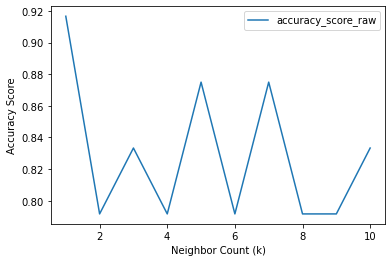

```python
# Here we apply the Knn algorithm on a range of different k's.
# This way we can see which K is the best for our data.

from sklearn.neighbors import KNeighborsClassifier as knn

max_neighbors = 10

k_outputs = {
    'k' : [],
    'accuracy_score_raw' : [],
    'accuracy_score' : []
}

for num_neighbors in range(1, max_neighbors+1):
    knn_model = knn(n_neighbors = num_neighbors)
    knn_model.fit(x_train, y_train)
    test_predictions = knn_model.predict(x_test)
    accuracy_score_raw = knn_model.score(x_test, y_test)
    accuracy_score = "{:.2%}".format(accuracy_score_raw)
    k_outputs['k'].append(num_neighbors)
    k_outputs['accuracy_score'].append(accuracy_score)
    k_outputs['accuracy_score_raw'].append(accuracy_score_raw)

k_selection_df = pd.DataFrame(k_outputs)

display(k_selection_df)
k_selection_df.plot(x='k', y='accuracy_score_raw', xlabel='Neighbor Count (k)', ylabel = 'Accuracy Score')
```

We can see from the above that the best number to use for K is simply 1. Let's look at a few more helpful evaluation metrics for our single neighbor model:

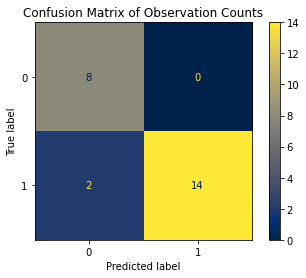

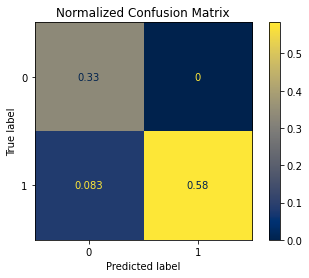

```python
knn_model = knn(n_neighbors = 1)
knn_model.fit(x_train, y_train)

test_predictions = knn_model.predict(x_test)

from sklearn.metrics import confusion_matrix, ConfusionMatrixDisplay

#Code for confusion matrix with raw counts
cm = confusion_matrix(y_test, test_predictions, labels=knn_model.classes_)
disp = ConfusionMatrixDisplay(confusion_matrix=cm,display_labels=knn_model.classes_)
disp.plot(cmap='cividis')
plt.title('Confusion Matrix of Observation Counts')
plt.show()

#Code for confusion matrix with proportions
cm = confusion_matrix(y_test, test_predictions, labels=knn_model.classes_,normalize='all')
disp = ConfusionMatrixDisplay(confusion_matrix=cm,display_labels=knn_model.classes_)
disp.plot(cmap='cividis')
plt.title('Normalized Confusion Matrix')
plt.show()
```

Let's look at the closest neighbors for our test dataset!

```python
neighbors = knn_model.kneighbors(x_test, n_neighbors = 1)
idxs = list(neighbors[1].flatten())
closest_n = x_train.iloc[idxs,]

eval_df = x_test.copy()
eval_df['closest_neighbor_idx'] = closest_n.index
display(eval_df)
```

|  | Q1 | Q4 | Q6 | Q7 | Q8 | Q9 | Q10 | Q11 | Q12 | Q13 | ... | Q46 | Q47 | Q48 | Q49 | Q50 | Q51 | Q52 | Q53 | Q54 | closest_neighbor_idx |
| --- | --- | --- | --- | --- | --- | --- | --- | --- | --- | --- | --- | --- | --- | --- | --- | --- | --- | --- | --- | --- | --- |
| 98 | 2.0 | 3.0 | 4.0 | 2.0 | 4.0 | 1.0 | 5.0 | 4.0 | 4.0 | 1.0 | ... | 3.0 | 5.0 | 1.0 | 5.0 | 1.0 | 5.0 | 4.0 | 1.0 | 4.0 | 10 |
| 8 | 5.0 | 3.0 | 5.0 | 2.0 | 2.0 | 1.0 | 4.0 | 5.0 | 3.0 | 2.0 | ... | 2.0 | 3.0 | 4.0 | 4.0 | 2.0 | 4.0 | 4.0 | 4.0 | 4.0 | 123 |
| 48 | 4.0 | 2.0 | 3.0 | 1.0 | 3.0 | 5.0 | 4.0 | 2.0 | 3.0 | 1.0 | ... | 5.0 | 5.0 | 1.0 | 5.0 | 4.0 | 3.0 | 3.0 | 3.0 | 5.0 | 87 |
| 46 | 4.0 | 2.0 | 5.0 | 5.0 | 3.0 | 1.0 | 5.0 | 1.0 | 1.0 | 1.0 | ... | 5.0 | 5.0 | 5.0 | 4.0 | 1.0 | 5.0 | 4.0 | 5.0 | 5.0 | 111 |
| 14 | 4.0 | 1.0 | 4.0 | 4.0 | 2.0 | 2.0 | 4.0 | 4.0 | 2.0 | 2.0 | ... | 5.0 | 4.0 | 4.0 | 5.0 | 3.0 | 5.0 | 3.0 | 4.0 | 5.0 | 86 |
| 54 | 2.0 | 1.0 | 4.0 | 1.0 | 4.0 | 2.0 | 5.0 | 4.0 | 4.0 | 1.0 | ... | 1.0 | 2.0 | 4.0 | 5.0 | 4.0 | 5.0 | 4.0 | 1.0 | 5.0 | 26 |
| 131 | 4.0 | 1.0 | 5.0 | 1.0 | 5.0 | 1.0 | 5.0 | 1.0 | 5.0 | 1.0 | ... | 5.0 | 3.0 | 1.0 | 5.0 | 2.0 | 5.0 | 5.0 | 1.0 | 5.0 | 59 |
| 42 | 1.0 | 1.0 | 4.0 | 2.0 | 4.0 | 1.0 | 4.0 | 3.0 | 2.0 | 2.0 | ... | 5.0 | 4.0 | 2.0 | 3.0 | 2.0 | 4.0 | 3.0 | 2.0 | 3.0 | 39 |
| 85 | 5.0 | 3.0 | 4.0 | 3.0 | 3.0 | 2.0 | 5.0 | 4.0 | 4.0 | 2.0 | ... | 5.0 | 5.0 | 2.0 | 4.0 | 5.0 | 5.0 | 4.0 | 1.0 | 5.0 | 86 |
| 15 | 2.0 | 1.0 | 3.0 | 4.0 | 2.0 | 4.0 | 5.0 | 1.0 | 3.0 | 4.0 | ... | 4.0 | 4.0 | 5.0 | 5.0 | 4.0 | 3.0 | 3.0 | 4.0 | 4.0 | 26 |
| 51 | 2.0 | 1.0 | 5.0 | 4.0 | 1.0 | 3.0 | 4.0 | 1.0 | 4.0 | 1.0 | ... | 5.0 | 4.0 | 1.0 | 4.0 | 4.0 | 4.0 | 5.0 | 1.0 | 4.0 | 43 |
| 31 | 4.0 | 1.0 | 2.0 | 5.0 | 5.0 | 2.0 | 4.0 | 3.0 | 3.0 | 2.0 | ... | 4.0 | 2.0 | 4.0 | 5.0 | 3.0 | 3.0 | 4.0 | 3.0 | 5.0 | 20 |
| 115 | 3.0 | 5.0 | 4.0 | 5.0 | 4.0 | 1.0 | 5.0 | 5.0 | 1.0 | 4.0 | ... | 5.0 | 1.0 | 4.0 | 5.0 | 4.0 | 4.0 | 5.0 | 5.0 | 2.0 | 103 |
| 61 | 1.0 | 2.0 | 3.0 | 4.0 | 1.0 | 4.0 | 5.0 | 3.0 | 1.0 | 2.0 | ... | 4.0 | 4.0 | 4.0 | 4.0 | 5.0 | 3.0 | 4.0 | 4.0 | 3.0 | 53 |
| 22 | 3.0 | 1.0 | 3.0 | 3.0 | 4.0 | 3.0 | 5.0 | 3.0 | 2.0 | 2.0 | ... | 5.0 | 3.0 | 4.0 | 5.0 | 5.0 | 5.0 | 4.0 | 5.0 | 3.0 | 112 |
| 4 | 3.0 | 1.0 | 4.0 | 3.0 | 5.0 | 3.0 | 5.0 | 3.0 | 3.0 | 1.0 | ... | 5.0 | 4.0 | 2.0 | 5.0 | 3.0 | 5.0 | 2.0 | 4.0 | 5.0 | 86 |
| 71 | 4.0 | 1.0 | 4.0 | 2.0 | 2.0 | 1.0 | 5.0 | 4.0 | 4.0 | 2.0 | ... | 5.0 | 4.0 | 2.0 | 2.0 | 2.0 | 4.0 | 2.0 | 1.0 | 4.0 | 123 |
| 100 | 4.0 | 1.0 | 4.0 | 4.0 | 4.0 | 1.0 | 5.0 | 1.0 | 3.0 | 2.0 | ... | 5.0 | 5.0 | 4.0 | 5.0 | 2.0 | 4.0 | 5.0 | 4.0 | 4.0 | 77 |
| 130 | 1.0 | 2.0 | 4.0 | 5.0 | 5.0 | 2.0 | 5.0 | 1.0 | 1.0 | 4.0 | ... | 4.0 | 5.0 | 5.0 | 5.0 | 4.0 | 4.0 | 4.0 | 5.0 | 4.0 | 20 |
| 121 | 4.0 | 1.0 | 4.0 | 3.0 | 2.0 | 4.0 | 5.0 | 1.0 | 4.0 | 1.0 | ... | 5.0 | 5.0 | 2.0 | 5.0 | 1.0 | 5.0 | 5.0 | 1.0 | 4.0 | 95 |
| 114 | 3.0 | 2.0 | 3.0 | 4.0 | 5.0 | 3.0 | 4.0 | 1.0 | 2.0 | 2.0 | ... | 4.0 | 5.0 | 3.0 | 5.0 | 4.0 | 3.0 | 5.0 | 3.0 | 4.0 | 112 |
| 105 | 4.0 | 4.0 | 3.0 | 4.0 | 2.0 | 1.0 | 5.0 | 4.0 | 3.0 | 2.0 | ... | 4.0 | 2.0 | 3.0 | 4.0 | 2.0 | 4.0 | 3.0 | 2.0 | 4.0 | 123 |
| 82 | 3.0 | 1.0 | 4.0 | 4.0 | 4.0 | 2.0 | 5.0 | 2.0 | 2.0 | 2.0 | ... | 5.0 | 4.0 | 1.0 | 4.0 | 1.0 | 4.0 | 3.0 | 1.0 | 5.0 | 93 |
| 16 | 4.0 | 2.0 | 5.0 | 4.0 | 3.0 | 1.0 | 5.0 | 2.0 | 2.0 | 2.0 | ... | 4.0 | 5.0 | 1.0 | 5.0 | 3.0 | 4.0 | 3.0 | 1.0 | 4.0 | 86 |

24 rows × 51 columns

```python
pd.get_option("display.max_columns")

display(bigfive_df.loc[[98,10],['Q1','Q14','Q24','Q34','Q45','Q9','Q19','Q29','Q39','Q50', 'is_extroverted']])
display(bigfive_df.loc[[48,87],['Q1','Q14','Q24','Q34','Q45','Q9','Q19','Q29','Q39','Q50', 'is_extroverted']])
```

|  | Q1 | Q14 | Q24 | Q34 | Q45 | Q9 | Q19 | Q29 | Q39 | Q50 | is_extroverted |
| --- | --- | --- | --- | --- | --- | --- | --- | --- | --- | --- | --- |
| 98 | 2.0 | 5.0 | 5.0 | 4.0 | 5.0 | 1.0 | 2.0 | 1.0 | 2.0 | 1.0 | 1 |
| 10 | 2.0 | 5.0 | 3.0 | 2.0 | 4.0 | 2.0 | 2.0 | 2.0 | 2.0 | 3.0 | 1 |

|  | Q1 | Q14 | Q24 | Q34 | Q45 | Q9 | Q19 | Q29 | Q39 | Q50 | is_extroverted |
| --- | --- | --- | --- | --- | --- | --- | --- | --- | --- | --- | --- |
| 48 | 4.0 | 5.0 | 5.0 | 4.0 | 3.0 | 5.0 | 3.0 | 3.0 | 3.0 | 4.0 | 0 |
| 87 | 4.0 | 4.0 | 5.0 | 4.0 | 1.0 | 2.0 | 3.0 | 2.0 | 4.0 | 4.0 | 0 |

Next we'll try to evaluate some other classification models, but since it will be the same process for the other models, we will also write a function!

```python
from sklearn.ensemble import GradientBoostingClassifier, RandomForestClassifier
from sklearn.svm import SVC
from sklearn.tree import DecisionTreeClassifier
from sklearn import tree
import graphviz
```

```python
# Decision trees
clf = DecisionTreeClassifier(max_depth = 3, random_state = 42)
clf.fit(x_train, y_train)

print(clf.predict(x_test))

tree.export_graphviz(clf, out_file="tree.dot",feature_names = x_train.columns,filled = True, proportion = True, class_names = ['Introverted','Extroverted'], leaves_parallel = True)

display(pd.DataFrame(y_train).value_counts())

with open("tree.dot") as f:
    dot_graph = f.read()
graphviz.Source(dot_graph)
```

```
[1 1 0 1 1 1 1 0 1 0 0 1 1 0 0 1 1 1 0 1 0 1 1 1]
```

```
is_extroverted
0                 48
1                 44
dtype: int64
```

[figure not shown]

```python
def evaluate_big5model(data, model, test_size = 0.2, normalize_cf = False, prediction_data = None):
    if model not in  ['knn','randomforest','boost','svm','decisiontree']:
        raise ValueError('Model {} not recognized. Model must be one of the following: {}'.format(model, ['knn','randomforest','boost','svm','decisiontree']))

    features = data.loc[:,'Q1':'Q54']
    target = data['is_extroverted']

    x_train, x_test, y_train, y_test = train_test_split(features, target, test_size = test_size, random_state = 42)

    init_model = None

    if model == 'knn':
        init_model = knn(n_neighbors = 1)
    elif model == 'randomforest':
        init_model = RandomForestClassifier()
    elif model == 'boost':
        init_model = GradientBoostingClassifier()
    elif model == 'svm':
        init_model = SVC()
    elif model == 'decisiontree':
        init_model = DecisionTreeClassifier()

    fitted_model = init_model.fit(x_train ,y_train)
    test_predictions = fitted_model.predict(x_test)
    accuracy_score = fitted_model.score(x_test,y_test)

    cm = confusion_matrix(y_test, test_predictions, labels=fitted_model.classes_)
    disp = ConfusionMatrixDisplay(confusion_matrix=cm,display_labels=fitted_model.classes_)
    disp.plot(cmap='cividis')
    plt.title('Confusion Matrix of Observation Counts for {}'.format(model))
    plt.show()

    print("Accuracy Score for {}: {:.2%}".format(model, accuracy_score))

    if isinstance(prediction_data, type(None)) == False:
        alex_features = prediction_data.loc[:,'Q1':'Q54']
        alex_target = prediction_data['is_extroverted']
        print('Alex Extroversion Prediction: {}'.format('Not Extroverted' if fitted_model.predict(alex_features)[0] == 0 else 'Extroverted'))
```

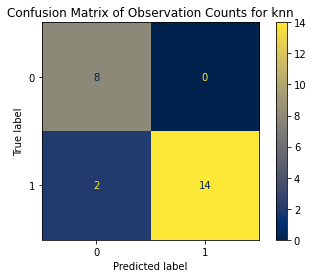

```
Accuracy Score for knn: 91.67%
Alex Extroversion Prediction: Not Extroverted
```

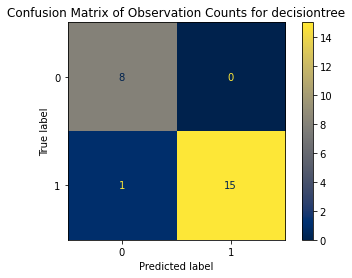

```
Accuracy Score for decisiontree: 95.83%
Alex Extroversion Prediction: Not Extroverted
```

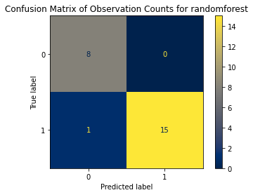

```
Accuracy Score for randomforest: 95.83%
Alex Extroversion Prediction: Not Extroverted
```

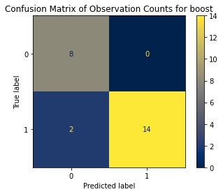

```
Accuracy Score for boost: 91.67%
Alex Extroversion Prediction: Not Extroverted
```

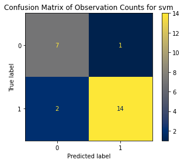

```
Accuracy Score for svm: 87.50%
Alex Extroversion Prediction: Not Extroverted
```

```python
evaluate_big5model(bigfive_df, model='knn', prediction_data = alex_df)
evaluate_big5model(bigfive_df, model='decisiontree', prediction_data = alex_df)
evaluate_big5model(bigfive_df, model='randomforest', prediction_data = alex_df)
evaluate_big5model(bigfive_df, model='boost', prediction_data = alex_df)
evaluate_big5model(bigfive_df, model='svm', prediction_data = alex_df)
```